# Notebook Structure

1. Import necessary dependencies
2. Create dataset
3. Create data visualizations using heatmap for correlation analysis
4. Create detailed heatmap with multiple combinations
5. How to interpret correlation matrix in heatmap

# Correlation

Correlation, in simple terms, is like noticing a connection or a relationship between two things. It tells us if these two things tend to change together, and in what way. It doesn't necessarily mean that one thing causes the other, just that they seem to be linked.

Think of it like this:

Positive Correlation:

- Example 1: Height and Weight: Generally, taller people tend to weigh more. As height increases, weight also tends to increase. This is a positive correlation.
- Example 2: Studying and Grades: Students who spend more time studying usually get better grades. As study time increases, grades tend to increase. This is another positive correlation.
- Example 3: Ice cream sales and temperature: On hotter days, people tend to buy more ice cream. As the temperature increases, ice cream sales tend to increase.

Negative Correlation:

- Example 1: Price and Demand: When the price of something goes up, people usually buy less of it. As price increases, demand tends to decrease. This is a negative correlation.
- Example 2: Exercise and Body Fat: People who exercise more often tend to have less body fat. As exercise increases, body fat tends to decrease. This is a negative correlation.
- Example 3: Altitude and Temperature: As you go higher up a mountain, the temperature usually gets colder. As altitude increases, temperature tends to decrease.

No Correlation:

- Example: Shoe size and intelligence: There's likely no connection between how big someone's feet are and how smart they are. One doesn't change predictably with the other. This would be an example of no correlation. Important Point:

Just because two things are correlated doesn't mean one causes the other. For example, ice cream sales and crime rates might both go up in the summer. This doesn't mean that buying ice cream makes people commit crimes! There could be another factor, like the warm weather, that leads to both more people being outside (and thus more opportunities for both ice cream sales and crime). This is a common mistake to avoid when thinking about correlation.

So, correlation simply shows us how much two things seem to move together, whether in the same direction, opposite directions, or not at all. It's a useful way to spot patterns, but it doesn't tell the whole story about cause and effect.

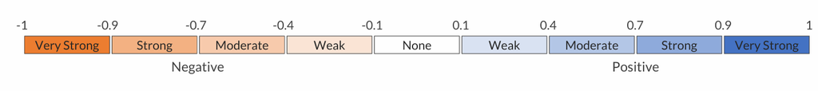

# 1. Import necessary dependencies

```python
# libraries & dataset
import matplotlib.pyplot as plt
import numpy as np
import seaborn as sns
import pandas as pd


sns.set_theme(style="darkgrid")
```

# 2. Create the dataset

```python
# 1. Create a dataset with around 10 numerical variables
# Using a dictionary to create the data, then converting to a DataFrame
data = {
    'StockPrice': np.random.normal(100, 15, 100),  # Example stock price
    'EPS': np.random.normal(5, 2, 100),             # Earnings per share
    'PE_Ratio': np.random.normal(20, 5, 100),        # Price-to-earnings ratio
    'DebtToEquity': np.random.uniform(0, 2, 100),   # Debt-to-equity ratio
    'ROA': np.random.normal(0.05, 0.02, 100),       # Return on assets
    'ROE': np.random.normal(0.10, 0.05, 100),      # Return on equity
    'MarketCap': np.random.lognormal(10, 2, 100),   # Market capitalization
    'RevenueGrowth': np.random.normal(0.08, 0.03, 100), # Revenue growth rate
    'DividendYield': np.random.uniform(0, 0.05, 100), # Dividend yield
    'Beta': np.random.normal(1, 0.3, 100)           # Beta coefficient
}
```

```python
df = pd.DataFrame(data)
df
```

|  | StockPrice | EPS | PE_Ratio | DebtToEquity | ROA | ROE | MarketCap | RevenueGrowth | DividendYield | Beta |
| --- | --- | --- | --- | --- | --- | --- | --- | --- | --- | --- |
| 0 | 67.849490 | 4.972568 | 17.097916 | 0.613809 | 0.055125 | 0.074775 | 2658.013626 | 0.102718 | 0.015225 | 0.589980 |
| 1 | 97.256475 | 6.456098 | 25.594408 | 0.829942 | 0.043979 | 0.131496 | 9281.259897 | 0.080700 | 0.009905 | 1.073769 |
| 2 | 70.523491 | 4.354351 | 29.169613 | 1.425555 | -0.008579 | -0.001972 | 503449.899802 | 0.065972 | 0.003285 | 0.114077 |
| 3 | 63.474045 | 5.521778 | 18.725791 | 0.772424 | 0.047581 | 0.108698 | 13446.830084 | 0.047705 | 0.044356 | 1.372264 |
| 4 | 102.161396 | 5.594255 | 18.312359 | 1.177010 | 0.072493 | 0.048046 | 8628.812338 | 0.086639 | 0.020992 | 0.789176 |
| ... | ... | ... | ... | ... | ... | ... | ... | ... | ... | ... |
| 95 | 121.366930 | 3.647392 | 13.691754 | 0.758255 | 0.049185 | 0.042173 | 48300.410035 | 0.124647 | 0.027279 | 0.660315 |
| 96 | 110.464351 | 6.926490 | 29.949046 | 0.742972 | 0.053785 | 0.130294 | 530198.471061 | 0.035950 | 0.005280 | 0.981277 |
| 97 | 109.694461 | 0.877349 | 22.649403 | 1.237054 | 0.030073 | 0.156386 | 8783.640735 | 0.124557 | 0.002265 | 0.980346 |
| 98 | 83.234951 | 6.101973 | 22.061173 | 1.266145 | 0.069662 | 0.108930 | 1041.615543 | 0.072749 | 0.032819 | 1.098358 |
| 99 | 125.494486 | 8.144484 | 27.945822 | 0.938570 | 0.027087 | 0.028277 | 5454.806703 | 0.009867 | 0.026758 | 0.972888 |

100 rows × 10 columns

```python
df.shape
```

```
(100, 10)
```

# 3. Correlation matrix creation and visualization using heatmap

### A. Create default heatmap from correlation matrix

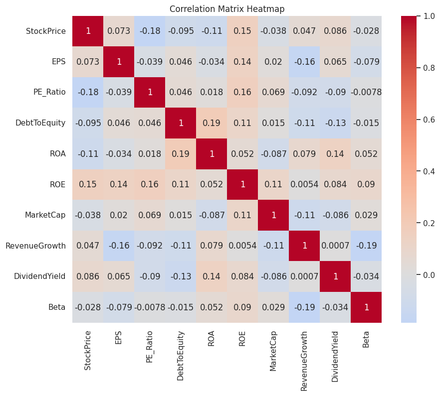

```python
# 2. Create heatmap as part of bivariate analysis (correlation matrix)
# Calculate the correlation matrix
correlation_matrix = df.corr()

# Create the heatmap
plt.figure(figsize=(10, 8))  # Adjust figure size for better readability
sns.heatmap(correlation_matrix, annot=True, cmap='coolwarm', center=0)
plt.title('Correlation Matrix Heatmap')
plt.show()
```